# missingness_check

Yunfei Yu, 1005976918

2026-03-21

```r
library(readxl)
library(dplyr)
library(tidyverse)
library(kableExtra)
library(knitr)
library(skimr)
library(naniar)
# library(VIM)
library(gtsummary)
library(gt)
library(forcats)
library(stringr)
library(ggplot2)
library(ggdist)
library(tidyquant)
```

```r
source("helper_functions.R")
```

```r
oath_data <- read_csv("Data/OATH_DATA_Labelled.csv")
dim(oath_data)
```

```
## [1] 231  95
```

# 1 Outline

1. Check row-wise and column-wise missing / completion rate
2. Explore missing patterns by variable group
1. Items in each scale
2. Demographics
3. Focusing on Exploration, Exploitation and De-implementation scales:
1. Explore demographic differences between missing and non-missing groups
2. Explore the differences between “actual missing” (NA, who did not complete the question) and people who chose 8
4. Based on 3b, decide whether to treat 8 as actual missing and drop, or treat as a distinct category and keep in subsequent analysis

# 2 Row-wise Completion Rate

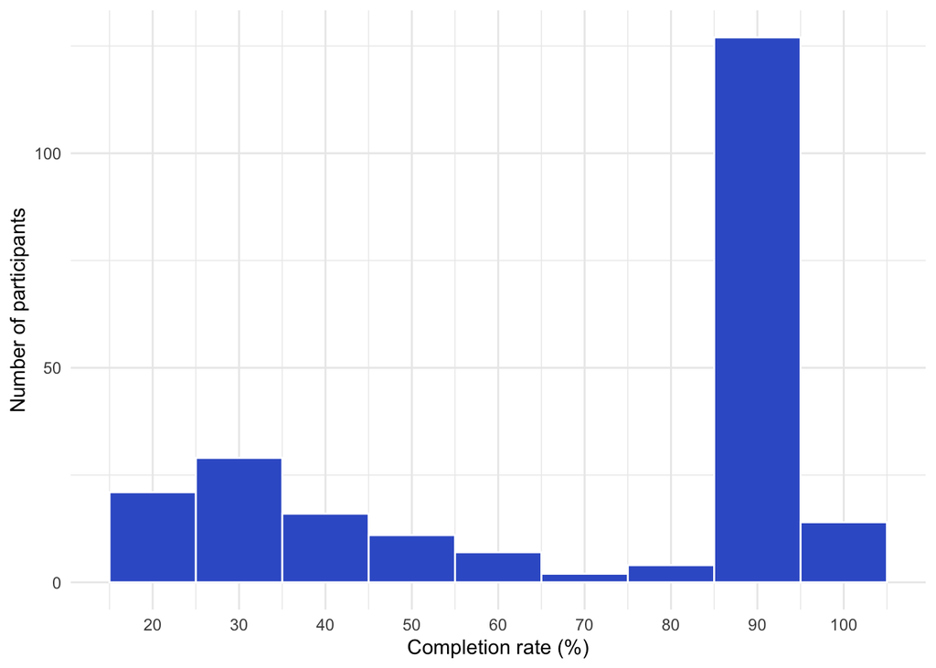

Survey completion rate by participant

```r
# check completion rate for each observation
oath_data$completion_rate <- rowMeans(!is.na(oath_data))

oath_data %>%
  ggplot(aes(x = completion_rate * 100)) +
  geom_histogram(binwidth = 10, color = "white", fill = "royalblue3") +
  scale_x_continuous(breaks = seq(0, 100, by = 10)) +
  labs(x = "Completion rate (%)",
       y = "Number of participants") +
  theme_minimal()
```

# 3 Missing Patterns by Variables

## 3.1 Missingness pattern across Exploration, Exploitation and De-implementation surveys

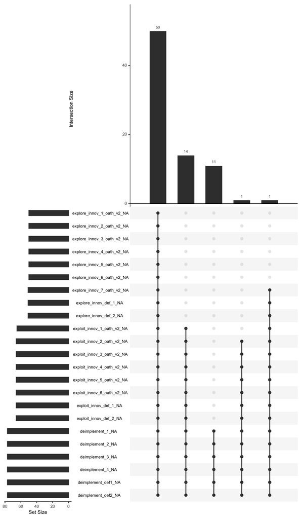

```r
learning_scales <- oath_data %>%
  select(starts_with(c("explore", "exploit", "deimplement")))

gg_miss_upset(learning_scales, nsets = ncol(learning_scales), mb.ratio = c(0.4, 0.6))
```

The Learning Ambidexterity scales and De-implementation scale appear to show highly systematic patterns of missingness. The most common pattern is skipping (missing) all questions in all three scales, followed by those who filled out only the exploration survey but missed the exploitation and de-implementation surveys entirely, and finally those who filled out the exploration and exploitation surveys, but not the de-implementation survey.

This suggests missingness is likely driven by an external factor (ex. specific groups of non-respondents, lost interest, or a specific survey is less relevant), rather than missing at random.

## 3.2 Missingness pattern across OCIS and Organizational Learning surveys

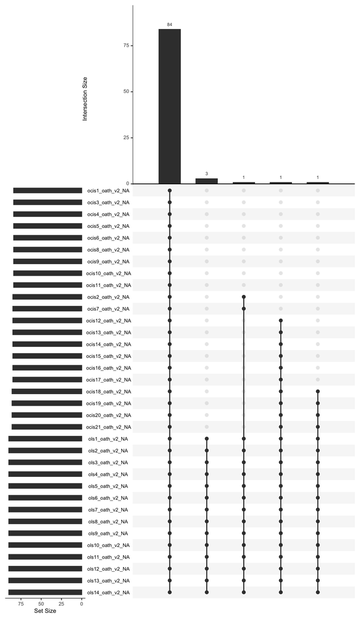

```r
org_scales <- oath_data %>%
  select(starts_with(c("ocis", "ols")))

gg_miss_upset(org_scales, nsets = ncol(org_scales), mb.ratio = c(0.3, 0.7))
```

## 4.3 Missingness Pattern for Demographics

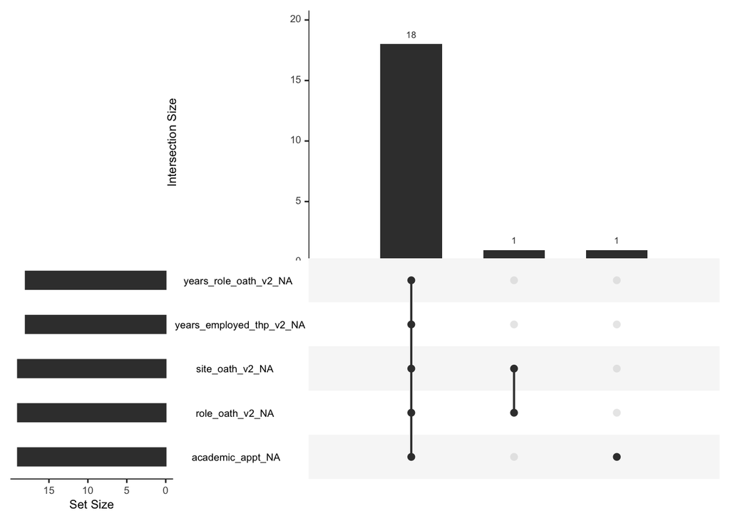

```r
demog_role <- oath_data %>%
  select(site_oath_v2, role_oath_v2, years_role_oath_v2, years_employed_thp_v2, academic_appt)
gg_miss_upset(demog_role, nsets = ncol(demog_role),  mb.ratio = c(0.5, 0.5))
```